# Git y GitHub

Curso R AEET 2025

Author

Elena Quintero

Published

09/01/2025

## ¿Por qué resulta útil el control de versiones?

**Nos evitan:**

- Sobreescribir archivos
- Múltiples versiones finales
- Trabajar por error en versiones no finales
- Creación de copias “en conflicto” cuando dos personas trabajan a la vez
- Ediciones sin control de cambios

**Nos permiten:**

- Sabers *quién* ha hecho *qué* y *cuándo*
- Llevar un registro de todos los cambios
- Deshacer cambios
- Facilitan la colaboración
- Ediciones sin control de cambios

## ¿Qué es Git?

[figure not shown]

Git es un sistema de **control de versiones** distribuido. Nos permite el seguimiento de cambios en nuestros archivos, colaborar con otras personas y manejar nuestros proyectos de forma más eficiente.

*Características clave de Git:*

- Local: Funciona completamente en tu máquina, no requiere internet para la mayoría de las operaciones.
- Distribuido: Cada usuario tiene su propio repositorio completo en su máquina, con todo el historial del proyecto y no depende de un servidor central para realizar muchas de las tareas (a diferencia de otros sistema de control).
- Línea de comandos: Git se usa principalmente a través de comandos en la terminal o consola.

## ¿Qué es GitHub?

[figure not shown]

GitHub es una **plataforma basada en Git** para el alojamiento de proyectos o repositorios, que facilita la colaboración entre personas y ofrece herramientas adicionales como pull requests, issues o acciones automatizadas, entre otras.

*Características clave de GitHub:*

- Remoto: Requiere internet para acceder a los repositorios almacenados en la nube.
- Interfaz gráfica: Proporciona una interfaz gráfica para visualizar y gestionar proyectos. Además existen apps de escritorio.
- Herramientas para equipos de personas: por ejemplo, revisión de código (pull requests), tareas y seguimiento de errores (issues), integración y automatización de procesos (GitHub Actions).

[figure not shown]

[Excuse me, do you have a moment to talk about version control? - Jennifer Bryan](https://doi.org/10.7287/peerj.preprints.3159v2)

## Instalación y Configuración Inicial

Hay que (1) hacerse una cuenta en GitHub, (2) instalar Git, (3) hacer que Git local hable con GitHub y (4) asegurarse de que RStudio puede hablar con Git local (y, por tanto, con GitHub). Esto se hará una única vez (por ordernardor).

Guía completa: https://happygitwithr.com

**1. Crear una cuenta en GitHub**

https://github.com

[Consejos para nombre de usuario](https://happygitwithr.com/github-acct.html)

**(1.5). Asegurar que R y R-studio estan instalados**

Y actualizados!

**2. Instalación de Git**

Primero asegurarse que Git no está ya instalado en nuestro ordenador (en la terminal: `which git` y `git --version` y `git config --list`)

https://happygitwithr.com/install-git - Instrucciones de instalación en diferentes sistemas operativos

https://happygitwithr.com/troubleshooting.html - Resolución de problemas durante la instalación

**3. Hacer que Git local hable con GitHub**

```r
install.packages("usethis")

library("usethis")

use_git_config(user.name = ”Jane Doe”, user.email = ”jane@example.org”)
```

**Crear y guardar Personal Access Token (PAT)**

```r
usethis::create_github_token()
```

Esto abrirá una ventana en la web de GitHub - Hacer click en ‘Generate token’ (bton verde).

Pegar y guardar el PAT:

```r
# install.packages("gitcreds")
# library("gitcreds")
gitcreds::gitcreds_set()
```

**GitHub Desktop App**

Git se puede operar a través de la terminal (difícil), a través de R Studio (medio) o a través de la aplicacion “GitHub desktop” (muy fácil).

Descarga de GitHub Desktop - https://desktop.github.com/download/

## Introducción a GitHub

**¿Qué es un repositorio?**

Un repositorio es un “contenedor” donde desarrollar un proyecto.

[figure not shown]

Figure: (Braga et al. 2023)

Un repositorio tiene numerosos apartados:

- Code - contenido del proyecto
- Issues - crear y gestionar problemas o tareas
- Pull requests
- Discusions
- Actions
- Project - tareas y manejo de proyectos
- Wiki - espacio para documentar proyecto
- Security
- Insights - estadísticas del proyecto
- Settings - configuración
- Watch/Fork/Star
- Commit history
- Contributors

… y más

## Flujo de Trabajo Básico con GitHub

1. Crear un repositorio en GitHub
2. Clonar un repositorio en Rstudio
3. Hacer cambios (nuevo fichero) y sincronizar `commit`
4. Subir cambios al repositorio remoto `git push`
5. Abrir issue en GitHub (e.g. nuevo plot)
6. Hacer cambios en R y sincronizar de nuevo (`commit` y `git push`)
7. Ver cambios en fichero `diff`
8. Hacer cambios en GitHub (e.g. README.md)
9. Descargar cambios del remoto `git pull`
10. Ver commit history del repositorio

## Colaboración en GitHub

Se puede pensar en el historial de un proyecto como una *linea del tiempo* de la que podemos generar ramas que trabajen en paralelo y que se pueden unir a la principal.

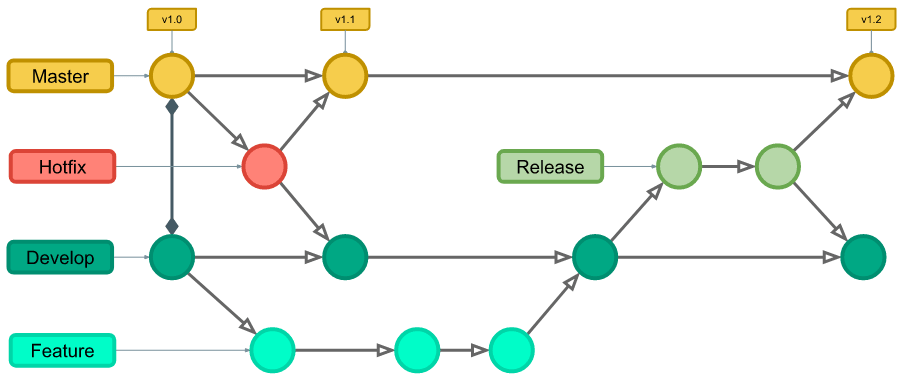

Image source: https://medium.com/@jacoblogan98/understanding-git-branching-5d01f3dda541

**Fork y Pull Request**

Hacer un `fork` es un modo de hacer una copia de un repositorio en tu cuenta para hacer cambios sin afectar el repositorio original. Un fork crea una rama o `branch` en la que poder trabajar en paralelo a la rama principal.

Una vez estamos seguros que nuestros cambios se pueden unir a la rama principal (master o `main`) hacemos un `pull request` - es una solicitud para que los propietarios del repositorio revisen y acepten los cambios.

Trabajar en diferentes ramas (branches) puede facilitar la colaboración y evitar conflictos en la rama principal.

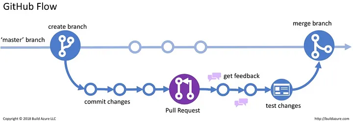

Image source: https://build5nines.com/introduction-to-git-version-control-workflow/

**Resolución de conflictos - Merge conflicts**

Git puede encontrar conflictos al intentar fusionar ramas que hay que arreglar manualmente. Esto sucede cuando ambas ramas han modificado las mismas líneas de un archivo - aparece un mensaje: “*Can’t automatically merge*”.

En estos casos, es necesario crear el pull request y resolver el conflicto “*Resolve conflicts*”.

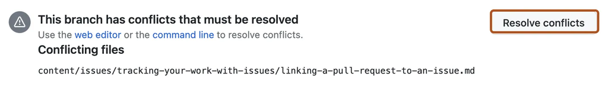

Git muestra dónde están los conflictos así:

`<<<<<<código del main=======código de la rama a unir>>>>>>`

Para resolverlo, debes elegir si conservar los cambios de la rama principal, los de la rama que deseas fusionar, o combinar ambos según sea necesario. Una vez realizada esta selección, Git permitirá completar la fusión creando un nuevo commit que integre ambas ramas.

## Buenas Prácticas

- Mantener repositorio ordenado (estructura clara y archivo README.md)
- Commits informativos (no sólo “update”)
- Mensajes de commit claros y cortos
- Hacer commits pequeños y frecuentes - evitar cambios grandes en un solo commit
- Usar verbos en presente para describir cambios
- Uso de .gitignore - ignorar archivos no deseados: e.g. “archivo.log”
- Uso de issues para:
  - dudas
  - dejar reflejadas decisiones importantes
  - peticiones a otro miembros
  - tareas pendientes
- Los issues se pueden etiquetar por temas (labels) y asignar a miembros (assignees)
- Colaboración en ramas cuando se trabaja en el mismo documento o necesita revisión

[figure not shown]

## Recursos Adicionales

Documentación oficial de Git: https://git-scm.com/doc

Documentación oficial de GitHub: https://docs.github.com

Tutorial interactivo: https://learngitbranching.js.org/

Beneficios extra con cuenta de GitHub Education - https://education.github.com/

Manuscritos sobre Git y GitHub:

Astigarraga, Julen, and Verónica Cruz-Alonso. 2022. “Se puede entender cómo funcionan Git y GitHub!” *Ecosistemas* 31 (1): 2332–32. https://doi.org/10.7818/ECOS.2332.

Blischak, John D., Emily R. Davenport, and Greg Wilson. 2016. “A Quick Introduction to Version Control with Git and GitHub.” *PLOS Computational Biology* 12 (1): e1004668. https://doi.org/10.1371/journal.pcbi.1004668.

Braga, Pedro Henrique Pereira, Katherine Hébert, Emma J. Hudgins, Eric R. Scott, Brandon P. M. Edwards, Luna L. Sánchez Reyes, Matthew J. Grainger, et al. 2023. “Not Just for Programmers: How GitHub Can Accelerate Collaborative and Reproducible Research in Ecology and Evolution.” *Methods in Ecology and Evolution* 14 (6): 1364–80. https://doi.org/10.1111/2041-210X.14108.

Bryan, Jennifer. 2017. “Excuse Me, Do You Have a Moment to Talk about Version Control?” e3159v2. PeerJ Preprints. https://doi.org/10.7287/peerj.preprints.3159v2.

Galeano, Javier. 2018. “Por qué usar GitHub? Diez pasos para disfrutar de GitHub y no morir en el intento:” *Ecosistemas* 27 (2): 140–41. https://doi.org/10.7818/ECOS.1604.

Perez-Riverol, Yasset, Laurent Gatto, Rui Wang, Timo Sachsenberg, Julian Uszkoreit, Felipe da Veiga Leprevost, Christian Fufezan, et al. 2016. “Ten Simple Rules for Taking Advantage of Git and GitHub.” *PLOS Computational Biology* 12 (7): e1004947. https://doi.org/10.1371/journal.pcbi.1004947.

Ram, Karthik. 2013. “Git Can Facilitate Greater Reproducibility and Increased Transparency in Science.” *Source Code for Biology and Medicine* 8 (1): 7. https://doi.org/10.1186/1751-0473-8-7.

### Este documento está basado en:

intro_git-github - Julen Astigarraga y Verónica Cruz https://github.com/DatSciR/intro_git-github

github-workshop - Developing efficient workflows with git & GitHub - Paco Rodríguez https://github.com/Pakillo/github-workshop